# Untitled

Stephan Röthlisberger

2024-03-25

# Risk and Return

## Time Series Format

When we deal with time siereis data set we have to mody first the format. Since we want to understand the development of securities over time. In order to use time-series in securitiy analysis, we first need to modify the data set into a time-series format. For that we need the packages `xts`.

```r
# First, download dataset

#Second, define the data column in the dataset as as.Date()
date = as.Date(A1[,1])
#date column is now an index! We need this to calculate

# Third, define time series format (xts)
A1ts <- xts(x = A1[,-1], order.by = date)
# -1 => all aport the first column
# ordered.by the created date column

# Print the Return
#head(A1ts)
```

Be careful when using the function `lag()` because different packages use it (e.g dplyr, stats..). In this case write the packages before the command like `stats::lag()`. So, you can use the function lag() of the stats package.

## Security Returns

Here we focus on the percentage change in the price of a securities. This is called securities return.

### Simple Returns

The daily price return is the percentage change in the price of a security today relative to its price yesterday. The formula can be written as followed:

$$\begin{equation*}
R_{i,t} = \frac{P_{i,t} - P_{i,t-1}}{P_{i,t-1}} =
\frac{P_{i,t}}{P_{i,t-1}} - 1
\end{equation*}$$

Where $R_{i,t}$ is the return of security i at time t, $P_{i,t}$ is the price of the security at time t.

Calculate return of `return_bigfour`

```r
# First load dataset

# Second, define date as as.date()
date_bf <- as.Date(dmy(A1_bigfour$Date))
#if there is an error charToDate(x) use dmy()

# Third, create xts format
A1_bigfour_ts <- xts(x = A1_bigfour[,-1], order.by = date_bf)
```

An important feature of xts objects is the date configuration ability. That is, by writing the dates of interest in brackets next to the xts object, we can define the exact period of observation:

```r
A1_bigfour_ts['1988-06-30/1989-12-29'][c(1:5),c(1:2)]
```

```
##            Nestle_PS Novartis_N
## 1988-06-30     4.103         NA
## 1988-07-29     4.006         NA
## 1988-08-31     4.123         NA
## 1988-09-30     4.133         NA
## 1988-10-31     4.264         NA
```

Now, we can calculate the returns for each security. We do this in two ways: First, with the formula above, then with the function `ReturnCalculate()`

```r
# Calculate Returns for Roche
## ALWAYS USE stats::lag(). THIS IS B/C DPLYR PACKAGE ASSUMES AN INCORRECT LAG WHEN BEING CALLED AND THUS THE MARKDOWN CANNOT BE RENDERED.

## Manually
A1_return_Roche_manual <- as.data.frame(A1_bigfour_ts$Roche_Holding / stats::lag(A1_bigfour_ts$Roche_Holding, 1) - 1)
# Results will have NA for the first row (since the first element has no previous element to form a return).

# Third, create xts format with new dataset
A1_return_Roche_manual_ts <- xts(x = A1_return_Roche_manual, order.by = date_bf)

## With function: Combination of the return calculate and xts function into one line
# using Return.calculate
A1_return_Roche_function <- xts(Return.calculate(A1_bigfour_ts$Roche_Holding, method =  "discrete"), order.by = date_bf)

# Get the sum to ensure they are the same. We do this by an ifelse statement, stating that if both sums are identical, it prints a 1
ifelse(mean(A1_return_Roche_function, na.rm = TRUE) == mean(A1_return_Roche_manual_ts, na.rm = TRUE), "Both calculations are identical", 0)
```

```
## [1] "Both calculations are identical"
```

A small note here: As you may have noticed, the first return will always be a NA value, since there is no lagged parameter for the first price. As such, every time we work with data that has missing or NA values, we need to modify the calculus by using the argument na.rm = TRUE in a specific function.

### Logarithmic Returns

Log returns are an approx of equal simple returns if volatility structure is relativly low (impling no large jumps between periods). We know that volatility is higher for riskier assets and longer horizont.

$$R_{i,t} = log(P_{i,t} - log(P_{i,t-1})$$

Advantage on log returns are the are addititive. This means we can state the sum of normally distributed will remain normal distributed (if they are not correlated). Consequently we can still rely on many statistically test that need normal distribution compared to multiplicative properties.

```r
# Let's calculate the log returns for Roche

## Manualy

A1_log_return_Roche_manual_ts <- xts(log(A1_bigfour_ts$Roche_Holding) - log(stats::lag(A1_bigfour_ts$Roche_Holding,1)), order.by = date_bf)

## With function

A1_log_return_Roche_function_ts <- xts((Return.calculate(A1_bigfour_ts$Roche_Holding, method = "log")), order.by = date_bf)

# Get the sum to ensure they are the same. We do this by an ifelse statement, stating that if both sums are identical, it prints a 1

ifelse(mean(A1_log_return_Roche_manual_ts, na.rm = T) == mean(A1_log_return_Roche_function_ts, na.rm = T), "Both calculation identical",0)
```

```
## [1] "Both calculation identical"
```

```r
# We can also compare both simple and log returns:
# Combine row of the vectors

Roche_log_simple = as.data.frame(
  rbind(mean(A1_return_Roche_manual_ts, na.rm = T), mean(A1_log_return_Roche_manual_ts, na.rm = T))
)

# Define columnnames and rownames
colnames(Roche_log_simple) = c("Return Roche")
rownames(Roche_log_simple) = c("Mean Return Simple", "Mean Return Log")

Roche_log_simple
```

```
##                    Return Roche
## Mean Return Simple  0.009988026
## Mean Return Log     0.008377684
```

### Accounting for Dividents: Total Returns

For companies that pay dividends, shareholders can reinvest the cash which implies we get compounded returns on the dividends.

Returns that include dividends reinvestment are known as *holding period returns* (HPR) or *total returns*

So the return is composed by a capital appreciation and a CF yield. On most days price return and total return are the same, since we only have changes on the capital appreciation. For non dividend paying stocks, price return and total return are the same.

But on ex dividends dates price return and total return deviate. The more dividens are paid in the investment horizon, the more changes are in the cumulative returns.

To account for this providers includes a adjustment for dividend in from of an adjusted close price.

### Truncating the data

Financial data are often exposed to outliers or extreme values. When this values are more noise than informative analyst remove them from the data. Often a cutoff in for of a Truncation is created that removes data which are greater than a certain i.th percentile (1-i-th). Here the function `quantile()` and `subset()`are often used.

```r
# We first calculate upper and lower cut-offs with the quantile() function e.g. for 99.5%

upper_cut <- as.numeric(quantile(A1_return_Roche_function, 0.995, na.rm = T))
lower_cut <- as.numeric(quantile(A1_return_Roche_function, 0.005, na.rm= T))

# We then take the ifelse statement to replace the most extreme values with the upper and lower cut-off scores
A1_return_Roche_function_cut <- subset(A1_return_Roche_function,
              A1_return_Roche_function >= lower_cut & A1_return_Roche_function <= upper_cut )
```

### Aritmetic vs. Geometric Returns

Arithmetic Returns: Use this when you want the expected return for a one period investment Geometric Returns: Use this when you want the cumulative return over an entire investment period

### Cumulative Returns

Using `cumprod()` function from the packages `PerformenceAnalytics` to calculate the cumulative returns we use for assessing the returns over an entire investment horizont

```r
# First, we need to cap the data set such that the first observation is no longer part of it (as this is a NA).

A1_return_Roche_ts_cap <- A1_return_Roche_function[-1,]

# Then, let's calculate the cumulative returns. To do so, we can use a handy feature of xts objects. By inserting the dates in brackets, we can define from when to when we want to have the analysis (thereby pinning-down a period of interest)

Roche_cum <- cumprod(1 + A1_return_Roche_ts_cap['1988-07-29/2000-12-29'])
```

Note that this package also has three other handy features: `cumsum()`, `cummin()` and `cummax`. The first calculates the sum of the subsequent returns up to a given date. The latter two calculate the maximum and minimum value of a period up to a certain point.

```r
# Let's calculate the sum, min and max values
Roche_sum <- cumsum(1 + A1_return_Roche_ts_cap['1988-07-29/2000-12-29'])
Roche_max <- cummax(A1_return_Roche_ts_cap['1988-07-29/2000-12-29'])
Roche_min <- cummin(A1_return_Roche_ts_cap['1988-07-29/2000-12-29'])

# Now, let's bind all of them together with the merge.xts function, and create a dataframe and name the columns:

cum_ret_all <- merge.xts(Roche_cum, Roche_sum, Roche_min, Roche_max)

colnames(cum_ret_all) <- c("Roche Cum Prod", "Roche Cum Sum", "Roche Cum Min", "Roche Cum Max")
```

We use `cumprod()`to draw returns

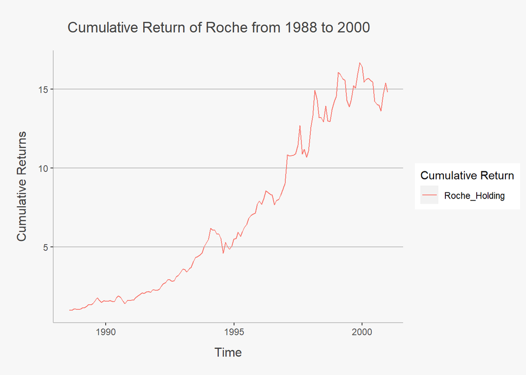

```r
tidy(Roche_cum) %>% ggplot(aes(x=index,y= value, color=series)) + geom_line() +
ylab("Cumulative Returns") + xlab("Time") + ggtitle("Cumulative Return of Roche from 1988 to 2000") +
  labs(color='Cumulative Return') +
theme(plot.title= element_text(size=14, color="grey26",
hjust=0.3,lineheight=2.4, margin=margin(15,0,15,45)),
panel.background = element_rect(fill="#f7f7f7"),
panel.grid.major.y = element_line(size = 0.5, linetype = "solid", color = "grey"),
panel.grid.minor = element_blank(),
panel.grid.major.x = element_blank(),
plot.background = element_rect(fill="#f7f7f7", color = "#f7f7f7"),
axis.title.y = element_text(color="grey26", size=12, margin=margin(0,10,0,10)),
axis.title.x = element_text(color="grey26", size=12, margin=margin(10,0,10,0)),
axis.line = element_line(color = "grey"))
```

### Periodic Transformation of Returns

We have the possibility with xts function to transform function to different periods.

```r
# First, we need to transform the prices data set into different intervals. Note that we have daily prices.
Roche_ts_daily <- to.daily(A1_bigfour_ts$Roche_Holding)
Roche_ts_weekly <- to.weekly(A1_bigfour_ts$Roche_Holding)
Roche_ts_monthly <- A1_bigfour_ts$Roche_Holding
Roche_ts_quarterly <- to.quarterly(A1_bigfour_ts$Roche_Holding)
Roche_ts_yearly <- to.yearly(A1_bigfour_ts$Roche_Holding)

# Then, we can calculate the returns for each periodicity accoringly:
Roche_ts_daily_ret <- Return.calculate(Roche_ts_daily, method = 'discrete')
Roche_ts_weekly_ret <- Return.calculate(Roche_ts_weekly, method = 'discrete')
Roche_ts_monthly_ret <- Return.calculate(Roche_ts_monthly, method = 'discrete')
Roche_ts_quarterly_ret <- Return.calculate(Roche_ts_quarterly, method = 'discrete')
Roche_ts_yearly_ret <- Return.calculate(Roche_ts_yearly, method = 'discrete')
```

### Annualising Returns

Instead of simply transforming time-series into different intervals, we take here periodic returns and calculate what their value would be when shifted to a different periodicity.

The daily to yearly formula for this would be:

$$R^{Ann}_{i,t} = (1+ R_{i,t})^365 -
1$$

Under the assumption $R_{i,t}$ are daily returns

In general, if we have different periods, we can shift the periodicity by simply taking the n’th power of the underlying return metric, whereas n defines the product of the different periodicities. As such, we get:

Daily to Weekly: n = 7 Daily to Monthly: n = 30 Daily to Annual: n = 252 (trading days) Weekly to Monthly: n = 4 Weekly to Annual: n = 52 Monthly to Annual: n = 12

Also, if you need to convert it into higher frequency, you take the 1/n’th power of the underlying return metric. As such:

Annual to Monthly: 1/n = 1/12 (the rest is analogous)

```r
# Get the mean monthly return for Roche
Roche_mean <- mean(A1_return_Roche_ts_cap['1988-07-29/2000-12-29'])

# Annualise it:

Roche_mean_ann <- (1+ Roche_mean)^12 - 1

#put together

Roche_average_return <- as.data.frame(cbind(Roche_mean, Roche_mean_ann))
colnames(Roche_average_return) <- c("Roche monthly mean", "Roche monthly mean annual")

# Print it
round(Roche_average_return)
```

```
##   Roche monthly mean Roche monthly mean annual
## 1                  0                         0
```

```r
# Delete unnesessary variables to clean enviromental
# List all objects in the workspace
objects <- ls()

# Filter objects that begin with "Roche_"
roche_objects <- objects[grep("^Roche_", objects)]

# Remove these objects
rm(list = roche_objects)
```

## Portfolio Returns

### Equal-weighted Returns

There to possible ways to calculate portfolio returns. Equal-weighted and value-based returns. For equal-weigthed (EW) returns implies that in all assets we invest equally. Meaning all assets is invested by 1/N.

This is equivalent to the mean of all security returns:

$$R_{p,t} = \frac{1}{N} \sum{R_{i,t}}$$

Where $R_{p,t}$ is the portfolio return at time t, $R_{i,t}$ is the security return at time t and N is the number of securities of the portfolio.

If we use this approach, we can easily calculate the mean return with the `rowMeans()` function:

```r
# First, the non matrix algebra solution

## We calculate the returns of all variables
A1_bf_ret_ts <- xts(Return.calculate(A1_bigfour_ts), order.by = date_bf)

# We delete the first row as this is NA
A1_bf_ret_ts <- A1_bf_ret_ts[-1,]

## We take the row to get the portfolio return at each period
bf_EW_ret_ts <- rowMeans(A1_bf_ret_ts, na.rm = T)

## Calculate annualized return for arithmetic value
bf_EW_ret_mean_ann_ts <- (1 + mean(bf_EW_ret_ts, na.rm= T))^12 -1
bf_EW_ret_mean_ann_ts
```

```
## [1] 0.1027313
```

We can derive the same results with matrix multiplication:

$$R_p = w^T R$$

```r
# First we define the average return vector of the securities:
return_vector <- rowMeans(A1_bf_ret_ts, na.rm = T)

# Then, we can create a vector consisting of average weights. Here, we have seven securities, so each return will be multiplied with 1/7.
weight_vector <- rep(1/length(return_vector),each=length(return_vector))

# Now calculate the matrix product:
mean_return_bigfour <- return_vector %*% weight_vector

# Annualise it:
bigfour_EW_ret_ts_mean_annual_matmul <- (1+mean_return_bigfour)^12 -1

# See if it is the same:
ifelse(bf_EW_ret_mean_ann_ts == bigfour_EW_ret_ts_mean_annual_matmul, "Both calculations are identical", 0)
```

```
##      [,1]
## [1,] "Both calculations are identical"
```

## Value-weighted Returns

Other than equal-weighted returns we account here for the company size when evaluating the portfolio performance. A value-weighted (VW) portfolio invests capital in proportion to the market capitalization of the securities in the portfolio. This means the bigger the company the more will be invested in it.

In VW strategies we use *past weights* because we do not know the market capitalization of a securities on time t, as the retun of all securities is not known. Only with the assumption of perfect forecasting we could calculate the actual weights. But this is unrealistic and is called look-ahead bias. Therefore we use weights just one period before the rebalancing.

The *market capitalization* is calculated

$$MC_{i,t} = P_{i,t} * SHROUT_{i,t}$$

Whereas $P_{i,t}$ is the price of security i at time t, $SHROUT_{i,t}$ are the outstanding shares and $MC_{i,t}$ is the market capitalization of security i on time t.